# WINN2

## THE MATHEMATICS GENDER GAP

### Effects On Student's and Parent's Attitude

###### Considering MATHEMATICS as an OVERALL SCORE

##### INVESTIGATION OVERVIEW

In this investigation, I wanted to require a better a glance at what attitudes of both the scholars and fogeys that contributed to overall PISA score's gender gap. the most focus was gender, different sorts of attitudes of scholars towards math (motivation, anxiety, interest, work ethic, behaviour) also because the the student's perception on how their parent's view math.

##### DATASET OVERVIEW

The given PISA 2012 dataset contained information from 485,490 students and 646 features. After the data cleaning process, I condensed the amount of features to 10: country, gender, overall math score, motivation score, anxiety score, interest score, work ethic score, behaviour score, and parent's attitude towards math score. All features under the attitude have a scale of 4 points, marking the highest positive attitude, to 1 point, marking a negative attitude. Anxiety works conversely, where one point shows a student to be less anxious (positive attitude) and 4 points being really anxious towards math with negative attitude.

#### DISTRIBUTION OF MATH SCORE

[figure not shown]

#### DISTRIBUTION OF ATTITUDE SCORES OF STUDENTS ON THE BASIS OF GENDER

[figure not shown]

#### GENDER PROPORTION of scholars WITH TOP PERCENTILE

We can see clearly here that because the top percentile increases, so does the gender gap. Initially, the feminine proportion was higher (due to the very fact that there was a rather more female students taking the survey as compared to the male students). But by the time we arrived to the highest (approximately) 20th percentile, the quantity of female students was adequate to the quantity of male students. All throughout the rise of top percentiles, we see that the proportion of male students strictly increases also . Notice that the further we get along the highest percentile of scholars , the gender gap's increase accelerates.

```python
##importing the requred libraries
import numpy
import pandas
import matplotlib.pyplot as plt
import seaborn

%matplotlib inline

plt.style.use('fivethirtyeight')
```

```python
##loading csv file
data = pandas.read_csv("C:/Users/Nimmy/Desktop/top_percent.csv")
```

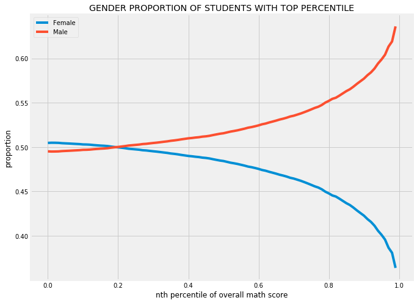

```python
##lineplot for gender proportion
plt.figure(figsize=(10,8))
seaborn.lineplot(data=data,x='nth_percentile',y='f_prop', label='Female')
seaborn.lineplot(data=data,x='nth_percentile',y='m_prop',label='Male')
plt.legend()
plt.title('GENDER PROPORTION OF STUDENTS WITH TOP PERCENTILE')##title
plt.ylabel('proportion')##ylabel
plt.xlabel('nth percentile of overall math score');##xlabel
```

### MOTIVATION SCORES BOF STUDENTS WITH TOP PERCENTILE ON THE BASIS OF GENDER

After analysing we can see that the motivation scoreof males is higher than the females.

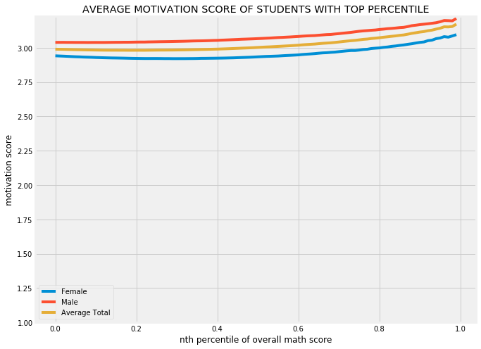

```python
##lineplot for motivation score
plt.figure(figsize=(10,8))
seaborn.lineplot(data=data,x='nth_percentile',y='f_motivation', label='Female')
seaborn.lineplot(data=data,x='nth_percentile',y='m_motivation', label='Male')
seaborn.lineplot(data=data,x='nth_percentile',y='avg_motivation', label='Average Total')
plt.legend()
plt.title('AVERAGE MOTIVATION SCORE OF STUDENTS WITH TOP PERCENTILE')##title
plt.ylim(bottom=1)##limit
plt.ylabel('motivation score')##ylabel
plt.xlabel('nth percentile of overall math score');##xlabel
```

### ANXIETY SCORES OF STUDENTS WITH TOP PERCENTILE ON THE BASIS OF GENDER

After analysing we can see that the anxiety score of females is higher than the males.

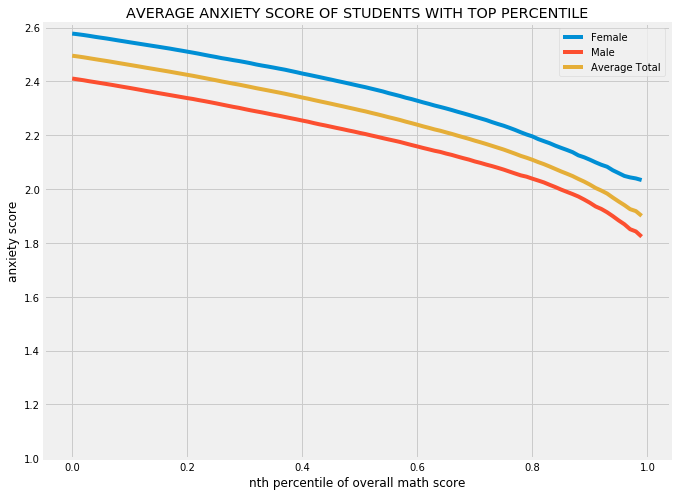

```python
##lineplot for anxiety score
plt.figure(figsize=(10,8))
seaborn.lineplot(data=data,x='nth_percentile',y='f_anxiety', label='Female')
seaborn.lineplot(data=data,x='nth_percentile',y='m_anxiety', label='Male')
seaborn.lineplot(data=data,x='nth_percentile',y='avg_anxiety', label='Average Total')
plt.legend()
plt.title('AVERAGE ANXIETY SCORE OF STUDENTS WITH TOP PERCENTILE')##title
plt.ylim(bottom=1)##limit
plt.ylabel('anxiety score')##ylabel
plt.xlabel('nth percentile of overall math score');##xlabel
```

### INTEREST SCORES BY TOP PERCENTILE STUDENTS BY GENDER

After analysing we can see that the interest score of males is higher than the females.

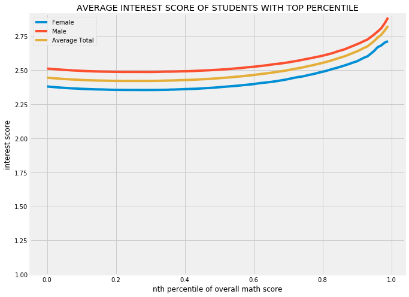

```python
##lineplot for interest score
plt.figure(figsize=(10,8))
seaborn.lineplot(data=data,x='nth_percentile',y='f_interest', label='Female')
seaborn.lineplot(data=data,x='nth_percentile',y='m_interest', label='Male')
seaborn.lineplot(data=data,x='nth_percentile',y='avg_interest', label='Average Total')
plt.legend()
plt.title('AVERAGE INTEREST SCORE OF STUDENTS WITH TOP PERCENTILE')##title
plt.ylim(bottom=1)##limit
plt.ylabel('interest score')##ylabel
plt.xlabel('nth percentile of overall math score');##xlabel
```

### WORK ETHIC SCORES OF STUDENTS WITH TOP PERCENTILE ON THE BASIS OF GENDER

After analysing we can see that the work ethic score of females is higher than the males.

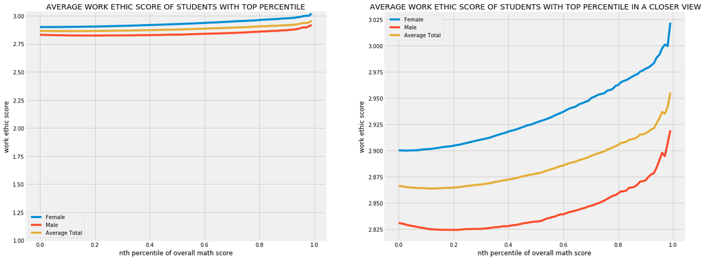

```python
##lineplot for work ethic score
plt.figure(figsize=(20,8))

plt.subplot(1,2,1)
seaborn.lineplot(data=data,x='nth_percentile',y='f_work_ethic', label='Female')
seaborn.lineplot(data=data,x='nth_percentile',y='m_work_ethic', label='Male')
seaborn.lineplot(data=data,x='nth_percentile',y='avg_work_ethic', label='Average Total')
plt.legend()
plt.title('AVERAGE WORK ETHIC SCORE OF STUDENTS WITH TOP PERCENTILE')##title
plt.ylim(bottom=1)##limit
plt.ylabel('work ethic score')##ylabel
plt.xlabel('nth percentile of overall math score')##xlabel
##closer view of work ethic score
plt.subplot(1,2,2)
seaborn.lineplot(data=data,x='nth_percentile',y='f_work_ethic', label='Female')
seaborn.lineplot(data=data,x='nth_percentile',y='m_work_ethic', label='Male')
seaborn.lineplot(data=data,x='nth_percentile',y='avg_work_ethic', label='Average Total')
plt.legend()
plt.title(' AVERAGE WORK ETHIC SCORE OF STUDENTS WITH TOP PERCENTILE IN A CLOSER VIEW')##title
plt.ylabel('work ethic score')##ylabel
plt.xlabel('nth percentile of overall math score');##xlabel
```

### PARENTAL SCORES OF STUDENTS WITH TOP PERCENTILE ON THE BASIS OF GENDER

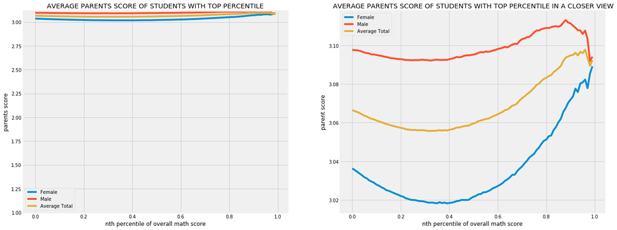

```python
##lineplot for parental score
plt.figure(figsize=(20,8))

plt.subplot(1,2,1)
seaborn.lineplot(data=data,x='nth_percentile',y='f_parents', label='Female')
seaborn.lineplot(data=data,x='nth_percentile',y='m_parents', label='Male')
seaborn.lineplot(data=data,x='nth_percentile',y='avg_parents', label='Average Total')
plt.legend()
plt.title('AVERAGE PARENTS SCORE OF STUDENTS WITH TOP PERCENTILE')##TITLE
plt.ylim(bottom=1)##limit
plt.ylabel('parents score')##ylabel
plt.xlabel('nth percentile of overall math score')##xlabel
##lineplot of parental score in a closer view
plt.subplot(1,2,2)
seaborn.lineplot(data=data,x='nth_percentile',y='f_parents', label='Female')
seaborn.lineplot(data=data,x='nth_percentile',y='m_parents', label='Male')
seaborn.lineplot(data=data,x='nth_percentile',y='avg_parents', label='Average Total')
plt.legend()
plt.title(' AVERAGE PARENTS SCORE OF STUDENTS WITH TOP PERCENTILE IN A CLOSER VIEW')##title
plt.ylabel('parent score')##ylabel
plt.xlabel('nth percentile of overall math score');##xlabel
```

### BEHAVIOUR SCORES OF STUDENTS WITH TOP PERCENTILE STUDENTS ON THE BASIS OF GENDER

After analysing we can see that the behaviour score of males is higher than the behaviour score of females.

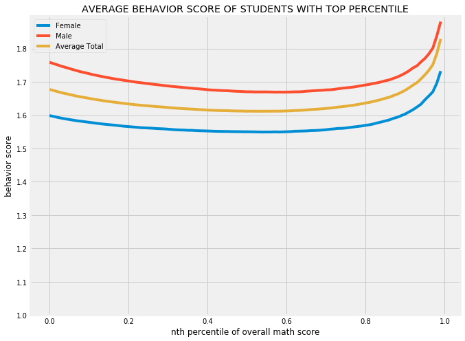

```python
##lineplot for behaviour scores
plt.figure(figsize=(10,8))
seaborn.lineplot(data=data,x='nth_percentile',y='f_behavior', label='Female')
seaborn.lineplot(data=data,x='nth_percentile',y='m_behavior', label='Male')
seaborn.lineplot(data=data,x='nth_percentile',y='avg_behavior', label='Average Total')
plt.legend()
plt.title('AVERAGE BEHAVIOR SCORE OF STUDENTS WITH TOP PERCENTILE')##title
plt.ylim(bottom=1)##limit
plt.ylabel('behavior score')##ylabel
plt.xlabel('nth percentile of overall math score');##xlabel
```

[figure not shown]

```python
##lineplot for analysing motivation score
plt.figure(figsize=(10,8))
seaborn.lineplot(data=data,x='nth_percentile',y='f_self', label='Female')
seaborn.lineplot(data=data,x='nth_percentile',y='m_self', label='Male')
seaborn.lineplot(data=data,x='nth_percentile',y='avg_self', label='Average Total')
plt.legend()
plt.title('AVERAGE SELF SCORE OF STUDENTS WITH TOP PERCENTILE')##title
plt.ylim(bottom=1)##limit
plt.ylabel('self score')##ylabel
plt.xlabel('nth percentile of overall math score');##xlabel
```